# Understanding Online Retail Consumer Behavior: Predictors of Spending, Product Choice, and Customer Satisfaction

Alice Le, Michelle Jiang, Hailey Tan, Iris Yin

# Motivation

The dataset describes consumer behavior in various perspectives, allowing us understand why people buy things and what affects their choices. When we know this, companies can design better products, websites, and shopping experiences that feel easier and more enjoyable to use.

It also helps stores plan better—like knowing how much to stock or when people are likely to buy certain items. Learning about shopping behavior can make recommendations more helpful without being intrusive or violating privacy.

It also teaches us about the emotions and social influences behind buying decisions. And on a bigger scale, it can help with things like sustainability and understanding consumer trends.

Overall, studying shopping behavior helps create smarter, more user-friendly, and more responsible shopping systems.

# Description of Dataset

We take the dataset from this Kaggle link: https://www.kaggle.com/datasets/ayeshasiddiqa123/customer-shopping-behavior-dataset

As stated, the dataset describes the shopping behavior of consumers, where each row represents an individual customer and their purchasing activity, including what they bought, how much they spent, how often they shop, their demographic attributes, and whether they used discounts or promotional codes.

The dataset is collected from an online retail platform. Generally, the dataset is of good quality with no missing values or duplicate rows. There are 3900 rows in total, and each row corresponds to a unique customer’s purchase transaction collected across a variety of U.S. states. The variables in the dataset are:

- `Customer.ID`: The unique ID of each customer
- `Age`: The age of customer (in years). Range from 18 to 70 years old.
- `Gender`: Gender of customer
- `Item.Purchased`: Type of item that the customer bought, such as Blouse, Sweater, Scarf, etc.
- `Category`: Broader category of the item purchased. There are 4 categories: Clothing, Footwear, Outerwear, and Accessories
- `Purchase.Amount..USD`: The amount spent on the purchased item, in US dollars
- `Location`: The US state where the customer resides
- `Size`: Size of the clothing item. There are 4 sizes: S, M, L, XL
- `Color`: Color of the clothing item
- `Season`: Season of the year that the customer made the purchase
- `Review.Rating`: Review rating the user gave for that purchase (from 0 to 5)
- `Subscription.Status`: Whether the customer subscribed to the store (“Yes” or “No”)
- `Shipping.Type`: The method of shipping used for the order (e.g., “Express”, “Free Shipping”, “Next Day Air”, “2-Day Shipping”, “Store Pickup”). Indicates speed and delivery preferences
- `Discount.Applied`: Whether a discount was applied to the purchase
- `Promo.Code.Used`: Whether a promotion code was applied to the purchase
- `Previous.Purchases`: The number of purchases the customer made before this transaction
- `Payment.Method`: The payment method used for the transaction. There are 6 options: Cash, Bank Transfer, Debit Card, Credit Card, Venmo, and Paypal
- `Frequency.of.Purchases`: How often the customer shops. The frequencies include Weekly, Fortnightly, Bi-weekly, Monthly, Every 3 Months, Quarterly, and Annually

# Research Questions

Stated below are our 3 research questions:

1. What factors predict how much a customer spends (Purchase Amount)?
2. How does season affect the types of items purchased and the color of the items?
3. How do discounts and shipping speed affect customer satisfaction (Review Rating)?

These research questions address core mechanisms of consumer behavior: spending determinants, seasonal purchasing patterns, and satisfaction drivers. Together, they allow us to examine how economic, temporal, and operational factors shape shopping outcomes in a way that is meaningful for both behavioral analysis and retail decision-making.

# Question 1: What factors predict how much a customer spends (Purchase Amount)?

To understand what drives customer spending, we start by examining how purchase amounts vary across key customer characteristics. Since purchase amount reflects a customer’s level of financial engagement, exploring its relationship with demographic and behavioral factors can help reveal broader spending patterns that can inform future marketing, segmentation, and retail strategies.

As a first step, we look at gender as a core demographic variable. To compare spending across gender categories, we use a boxplot of purchase amount. This visualization highlights typical spending levels, the spread of purchase amounts, and differences in variability between groups, providing a clear and intuitive foundation for identifying factors that may predict customer spending.

## Purchase Amount by Gender

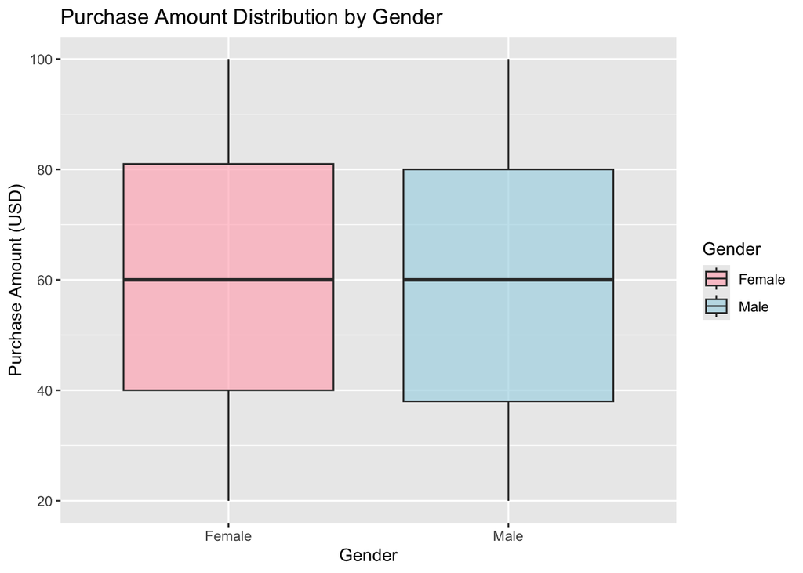

Similarly, we conducted a t-test of purchase amount by gender to more thoroughly depict these differences. Our test outputs a relatively high p-value of 0.3378, indicating that there is no significant difference in the spending and purchase amounts between male and female genders.

This comparison helps establish that gender might not meaningfully drive differences in spending behavior. And thus for our research question, this finding is relevant as it suggests we should look beyond basic demographics. As the distributions are nearly identical, gender-based segmentation would likely not improve predictions of customer spending.

Given the minimal differences observed here, our next step is to examine whether location provides stronger explanatory power as looking at purchase amount by geographic area may uncover regional spending patterns or market-level differences that gender alone cannot capture. The spatial graph below is especially effective since location-based trends are easier to interpret visually than in tables or non-spatial charts. By mapping average purchase amounts across the U.S., we can quickly identify clusters, regional contrasts, and potential spending hotspots.

## Average Purchase Amount by Location

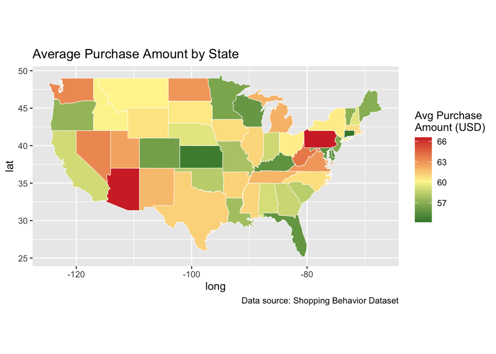

Understanding these trends can provide actionable insights for regional strategy. Retailers can focus premium products, loyalty programs, and targeted campaigns in high-spending markets while emphasizing value pricing and promotions in lower-spending areas. Beyond retail, such insights support more effective site selection, forecasting, and resource allocation.

## Purchase Amount by Purchase Method

[figure not shown]

Next, we analyzed the purchase amount based on the variable of purchase method (ie the payment method). To evaluate whether payment method plays a meaningful role in predicting how much a customer spends, we compared the distribution of purchase amounts across all payment types using a boxplot. Each box represents the spread of purchase amounts for a specific payment method. The medians for all methods are clustered around $60, indicating that the typical purchase amount is nearly identical regardless of how customers choose to pay. While Credit Card and Debit Card show slightly higher medians and upper quartiles, and Venmo exhibits a somewhat lower median with a wider spread, these differences are small and not practically meaningful. The overall pattern suggests that purchase amount remains consistent across payment options, with only minor variations in variability. This conclusion is supported by the ANOVA test, which returned a p-value greater than 0.05, indicating no statistically significant difference in mean purchase amount between payment methods. Thus, payment method does not appear to be a strong predictor of how much a customer spends.

## Purchase Amount by Age

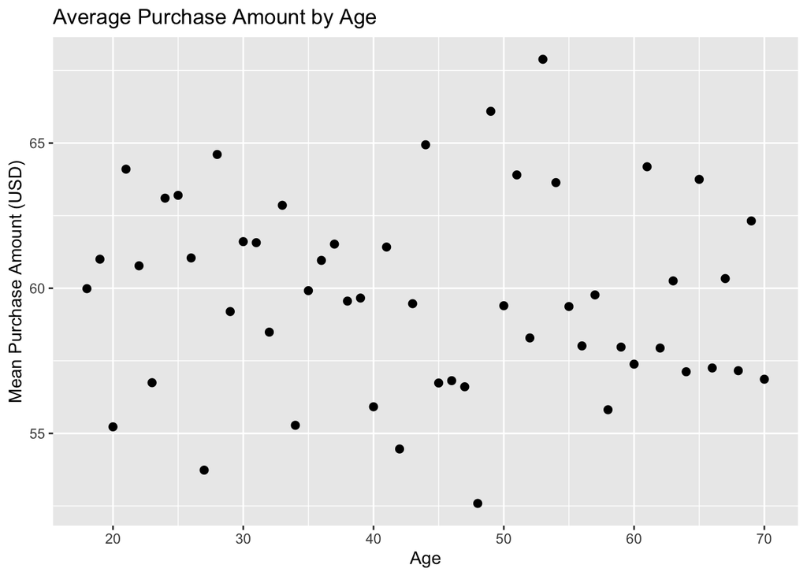

To investigate whether age helps explain or predict how much a customer spends, we examined the average purchase amount at each individual age. Each point in the scatterplot represents one age and the mean spending of customers at that age. The plot shows that most ages cluster within a narrow range of roughly $55–$65, indicating that typical purchase size remains relatively stable across the age distribution. There is no noticeable upward or downward trend, suggesting that age is not a meaningful driver of spending behavior. This visual finding is confirmed by the Pearson correlation test, which produced a correlation coefficient of –0.01, which is close to 0. Because this value indicates no significant linear association between age and purchase amount, we conclude that age does not meaningfully predict how much a customer spends.

## Purchase Amount by Customer Loyalty

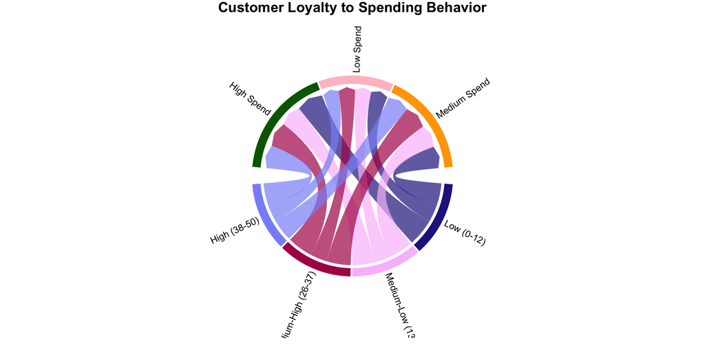

This chord diagram maps customer loyalty quartiles (bottom) to spending tiers (top), with ribbon width showing how many customers fall into each pairing. The most striking feature is the near-perfect symmetry across the diagram. All four loyalty groups, Q1 through Q4, send almost identical proportions of customers into Low, Medium, and High spending tiers. Instead of strong funnels into specific categories, the ribbons spread out evenly, forming a balanced, uniform pattern with no dominant pathways between loyalty level and spending behavior.

This symmetry reinforces that loyalty does not predict purchase amount. If highly loyal customers spent more, Q4 would show thick ribbons flowing to the High tier and thinner ones to Low, but the distribution is virtually the same for every quartile. Combined with earlier findings that gender also shows minimal predictive power, this suggests spending is shaped more by situational factors like product type, timing, or promotions than by customer history. For retailers, this means increasing per-transaction revenue requires focusing on merchandising, bundling, and purchase context rather than relying on loyalty to drive higher spending.

## Question 2: How does season affect the types of items purchased and the color of the items?

Besides just looking at what demographics can impact the purchase amount, we also wanted to analyze the trend of popularity of different items throughout the year, as well as the colors most popular at each season. We want to see if certain items, such as winter wear, actually is more frequently purchased in the winter/colder seasons vs the warmer seasons. Similarly, we want to see if, for example, brighter colors actually are more popular in the warmer seasons. This can greatly help business owners understand what items to put out at each season and what colors of items consumers like the most, which can help businesses grow.

## Item Purchases by Season

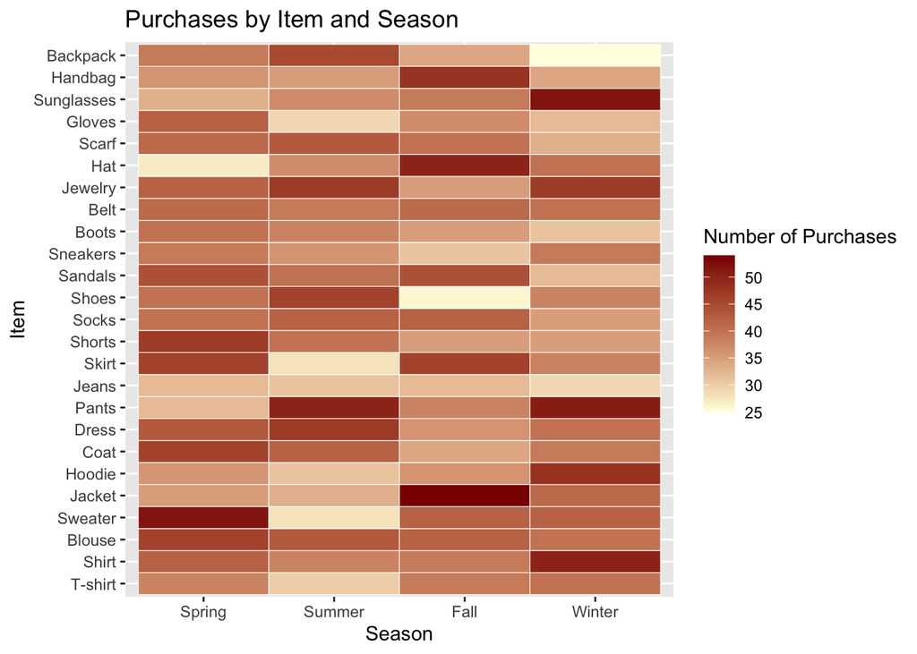

This heatmap displays how frequently each type of item is purchased across the four seasons. Darker colors represent higher numbers of purchases, while lighter shades indicate lower counts. We can see that there are some clear seasonal patterns from the heatmap. We can see that in the Spring and Fall, there is relatively balanced purchasing across many categories. However, in the Spring, we can see that there is a peak in purchases of sweaters. Summer shows strong spikes in items such as pants, jewelry, shoes, and dresses, reflecting typical seasonal demand for lighter clothing and accessories. In the Fall, we can see that there is a major spike in purchases for jacekts, hats, and handbags. This could reflect the changing of weather, so a greater need for warmer clothing. Winter, on the other hand, shows the highest concentration of purchases for cold-weather items such as pants, shirts (not t-shirts), and hoodies, all of which appear in darker shades in the Winter column.

However, it is interesting to note that there are also some unexpected purchases as well. For example, sunglasses are most popular in the winter, but we would usually associate sunglasses with the summertime. Additionally, scarves, which are a winter staple, are least commonly bought in the winter.

Overall, the heatmap effectively illustrates how item purchases shift with the seasons and highlights both seasonal and non-seasonal product categories.

## Item Colors by Seasonal Purchase Pattern

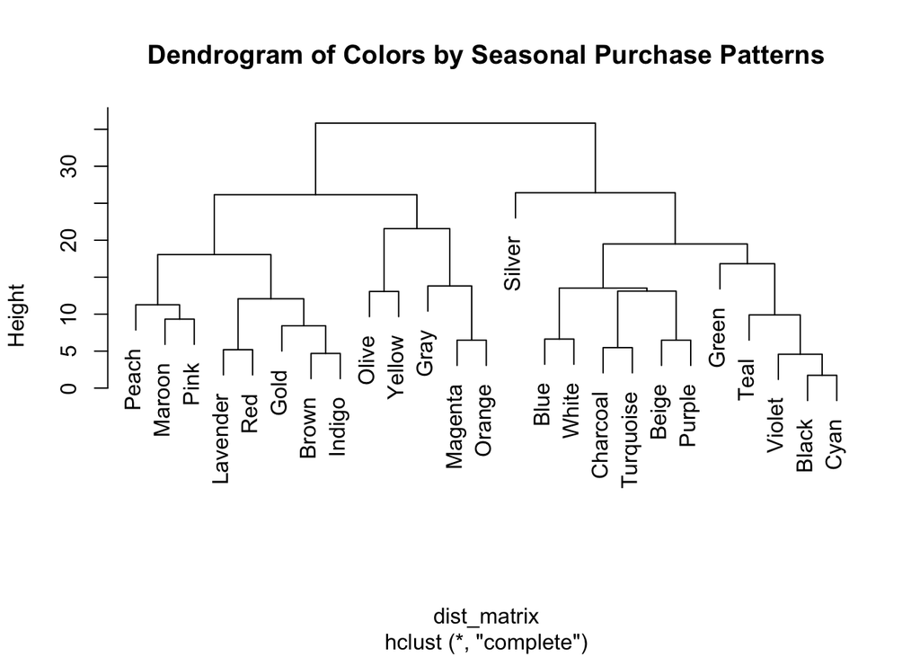

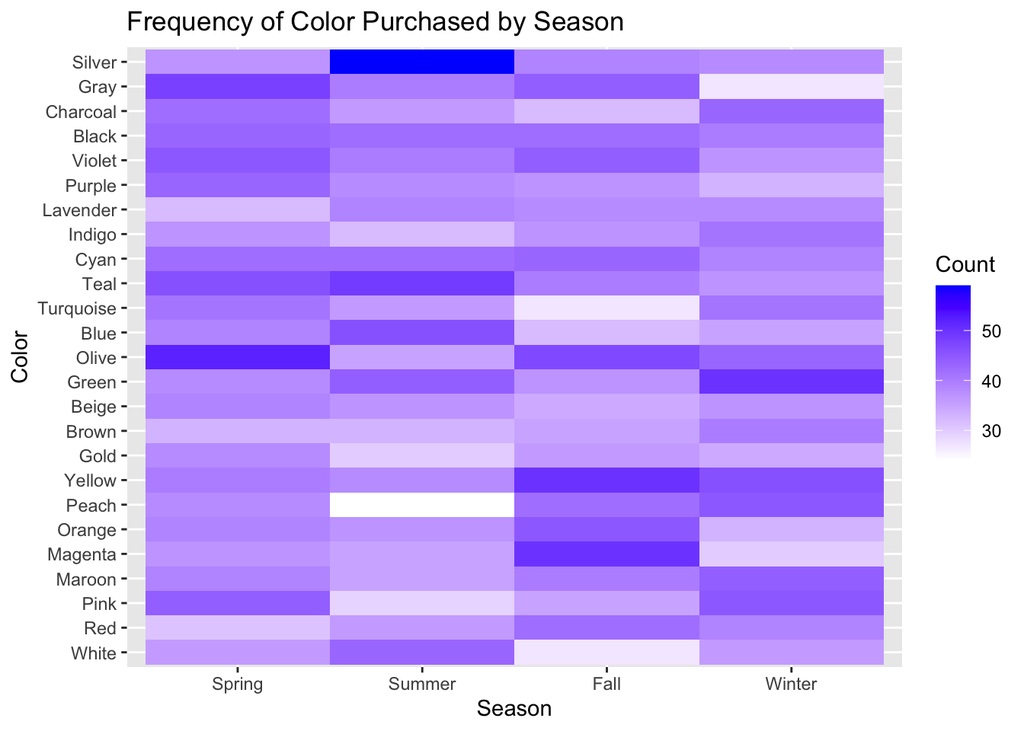

The dendrogram and heatmap together reveal clear patterns in how customers purchase different colors throughout the year. Examining the branch heights in the dendrogram provides insight into the similarity between clusters. Colors that join low on the dendrogram share very similar seasonal purchase patterns, while clusters that merge at higher branch points indicate more distinct behavior. From the dendrogram, we can see that certain colors naturally cluster together. For example, warmer shades of red (like peach, maroon, and pink) are closely clustered together. Similarly, cooler colors like black, cyan, violet, teal, and green cluster together.

The heatmap shows the frequency of purchases for each color in each season, with darker shaded cells indicating higher counts of purchases. This confirms the patterns we saw in the dendrogram and shows clear differences in purchase intensity across seasons for each cluster. We can see from the heatmap that in the fall, warmer colors are purchased with higher frequency, such as magenta, orange, and yellow. In the Winter, cooler toned colors are more popular, such as green. In the Spring, more neutral colors like olive and gray are popular. In the summer, we see that silver is very popular (possibly because of jewelery) and other bright colors like teal and blue are most frequently purchased. Overall, the combined visualization suggests that customers’ color preferences are strongly seasonal, with identifiable groups of colors that are consistently purchased together at particular times of the year. This clustering can inform targeted marketing strategies, seasonal promotions, or inventory planning by highlighting which colors are likely to be popular in specific seasons.

# Question 3: How do shipping speed and discount affect customer satisfaction (Review Rating)?

Shipping speed and discounts are key components of the customer experience, and both may meaningfully influence how satisfied customers feel with their purchase. Hence, we would visualize the distribution of customer satisfaction across different shipping methods and whether there are discount applied using violin plots. Besides providing the the 5-number summary like what a box plot would, a violin plot also shows the distribution so we can examine whether there is skewness or outliers as well.

Then, we would conduct an ANOVA test to examine the mean review ratings across 6 different shipping methods and a two-sample t-test to compare review ratings between two groups (“Yes” vs. “No”). These tests would help us answer whether in this dataset, shipping speed and discount have a statistically significant relationship with customer satisfaction.

## Review Raings by Shipping Type

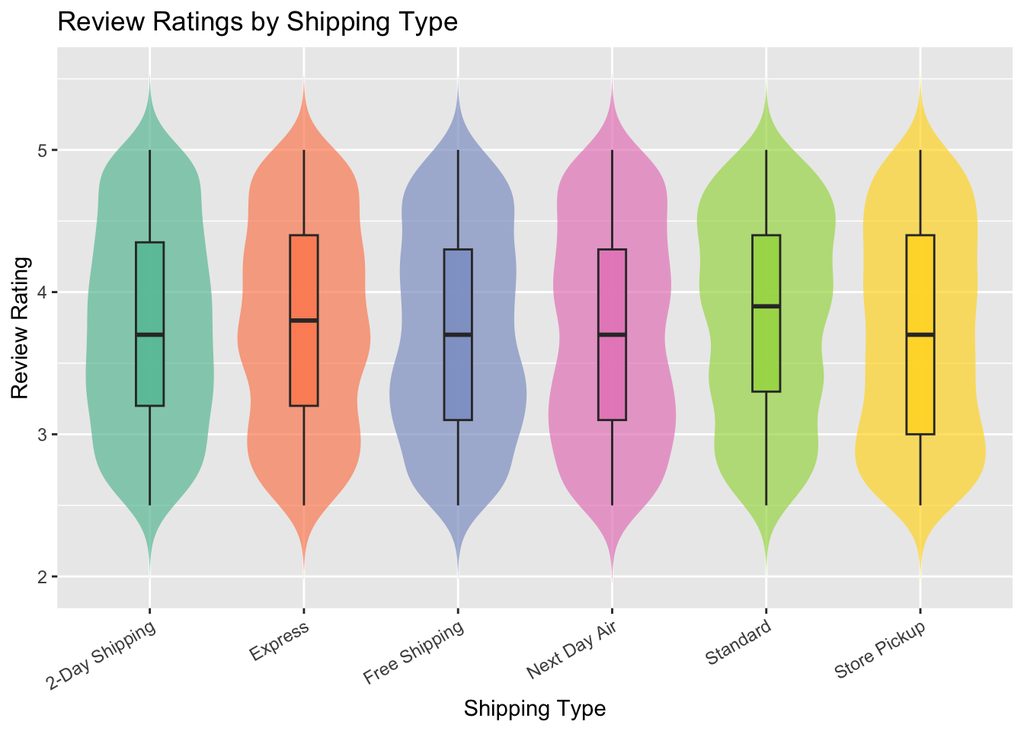

```
##                 Df Sum Sq Mean Sq F value Pr(>F)
## Shipping.Type    5      6  1.2048   2.353 0.0384 *
## Residuals     3894   1994  0.5121
## ---
## Signif. codes:  0 '***' 0.001 '**' 0.01 '*' 0.05 '.' 0.1 ' ' 1
```

Because the p-value for the ANOVA test is smaller than 0.05, we can conclude that average satisfaction differs across at least some shipping categories. However, when accompanying with the graph above, we see that there’s not much variation in the distribution of average rating across shipping types. Hence, we can say that while shipping type may have a statistically detectable association with review ratings, the practical differences between shipping methods are likely minimal.

## Review Raings vs. Discount Applied

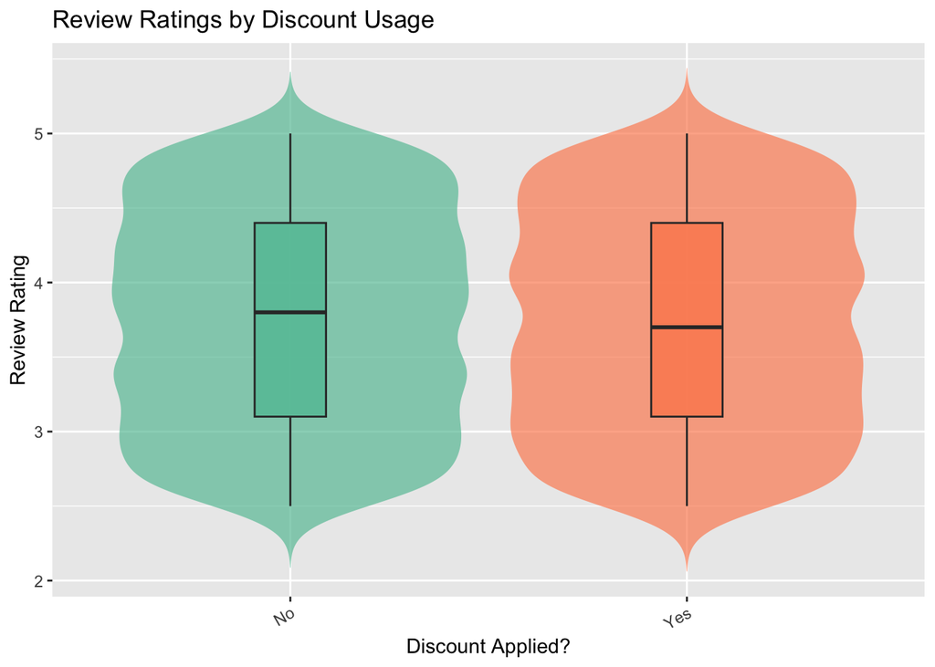

The violin plot comparing review ratings for customers who did and did not receive a discount shows that the two groups have nearly identical distributions. Both groups center around ratings of approximately 3.7, with very similar spreads and shapes. There is no visible indication that receiving a discount leads to higher or lower satisfaction. The substantial overlap between the groups suggests little practical difference.

```
##
##  Welch Two Sample t-test
##
## data:  Review.Rating by Discount.Applied
## t = 0.77934, df = 3604.9, p-value = 0.4358
## alternative hypothesis: true difference in means between group No and group Yes is not equal to 0
## 95 percent confidence interval:
##  -0.02737548  0.06349679
## sample estimates:
##  mean in group No mean in group Yes
##          3.757715          3.739654
```

The difference in mean ratings between customers who did not receive a discount (mean = 3.758) and those who did (mean = 3.740) is not statistically significant (t = 0.779, p = 0.436). The 95% confidence interval for the mean difference includes a zero (–0.027 to 0.063), indicating that any difference is small and likely due to random variation. Overall, the evidence suggests that discount usage does not meaningfully influence customer satisfaction.

From this dataset, we can conclude that the usage of discount does not affect rating. Even though the ANOVA test shows that there is statistical significance between shipping type and rating, the violin plots suggest there is not much variation.

# Conclusion

To conclude, our analysis examined three aspects of online retail behavior, which were spending predictors, seasonal purchasing patterns, and satisfaction drivers. Most variables, such as gender, age, payment method, and customer loyalty, showed little correlation with purchase amount, indicating that demographic and behavioral traits do not strongly shape spending levels. Location, however, emerged as a meaningful predictor, with clear regional differences such as higher spending in Arizona and Pennsylvania. These results suggest that geographic market characteristics play a more influential role in transaction size than individual customer attributes, making regional targeting an important strategic consideration.

Seasonal patterns were more predictive in explaining what customers buy. Item type and color preferences aligned with traditional trends, where outerwear and warm tones were more common in the fall, whereas lighter clothing and cool tones were more predominant in the summer. However, there were a few surprises, such as winter sunglasses purchases, which could hint at additional situational factors, such as black friday deals or discounted prices for nonseasonal attire. For customer satisfaction, shipping speed showed a statistically significant but modest effect on review ratings, with standard and express shipping performing slightly better than other options. Discounts, however, had no noticeable impact, indicating that operational factors like delivery reliability contribute more to satisfaction than price incentives.

# Evaluation/Future work

While this project addressed our three main research questions, there are still many different unanswered questions that we can explore. These questions came up as we were analyzing our data, however we weren’t able to fully delve into them due to limitations on this dataset and the analytical tools we learned in this class.

First, we were thinking about further analyzing the long-term shopping habits of these individuals. Currently, the dataset only provides information about singular purchases. However, having access to people’s purchases over time would allow us to analyze questions such as how does shopping frequency affect people’s spending over time? Additionally, this would provide more information than the loyal customer variable and give us more context about their variable.

Additionally, in this class we never covered any topics related to causal inference, which could be useful with our research questions. All of the analyses that we did in this report has been based on correlations and trends. However, if we were able to conduct controlled experiments (which is unlikely given the nature of the dataset) or use specialized causal inference methods, we could see which factors actually drive changes in outcomes. This would allow us to predict the effects of business actions and help businesses make better decisions.